# Norma Qrupları və Standartlaşma: Test Normalarının Qurulması

## 3.2 Sinif Normalarının Qurulması

```r
# Sinif səviyyəsi təyini
test_performance <- test_performance %>%
  mutate(
    Sinif = case_when(
      Yaş == 6 ~ 1,
      Yaş == 7 ~ 2,
      Yaş == 8 ~ 3,
      Yaş == 9 ~ 4,
      Yaş == 10 ~ 5,
      Yaş == 11 ~ 6,
      Yaş == 12 ~ 7,
      Yaş == 13 ~ 8,
      Yaş == 14 ~ 9,
      Yaş == 15 ~ 10,
      Yaş == 16 ~ 11,
      Yaş >= 17 ~ 12
    )
  )

# Sinif normaları
grade_norms <- test_performance %>%
  group_by(Sinif) %>%
  summarise(
    N = n(),
    Orta = round(mean(Test_Score), 1),
    SD = round(sd(Test_Score), 1),
    P25 = round(quantile(Test_Score, 0.25), 1),
    P50 = round(quantile(Test_Score, 0.50), 1),
    P75 = round(quantile(Test_Score, 0.75), 1),
    P90 = round(quantile(Test_Score, 0.90), 1),
    P95 = round(quantile(Test_Score, 0.95), 1),
    .groups = 'drop'
  )

kable(grade_norms, caption = "Sinif Normları Cədvəli")
```

Sinif Normları Cədvəli

| Sinif | N | Orta | SD | P25 | P50 | P75 | P90 | P95 |
| --- | --- | --- | --- | --- | --- | --- | --- | --- |
| 1 | 1000 | 21.3 | 11.3 | 13.0 | 21.4 | 29.1 | 35.4 | 40.1 |
| 2 | 1000 | 26.6 | 11.8 | 18.7 | 26.3 | 34.5 | 41.7 | 46.0 |
| 3 | 1000 | 30.0 | 11.1 | 23.1 | 29.8 | 37.4 | 44.2 | 48.1 |
| 4 | 1000 | 36.0 | 11.5 | 28.0 | 35.6 | 43.9 | 51.4 | 55.4 |
| 5 | 1000 | 40.8 | 11.5 | 32.8 | 40.8 | 48.8 | 55.6 | 60.1 |
| 6 | 1000 | 46.0 | 12.1 | 37.6 | 46.4 | 54.3 | 60.7 | 66.0 |
| 7 | 1000 | 50.2 | 11.6 | 42.5 | 49.9 | 57.8 | 64.9 | 69.4 |
| 8 | 1000 | 55.5 | 12.0 | 47.4 | 55.6 | 63.7 | 71.0 | 75.8 |
| 9 | 1000 | 60.8 | 11.6 | 53.0 | 60.9 | 68.5 | 75.9 | 80.1 |
| 10 | 1000 | 65.5 | 12.1 | 57.3 | 65.0 | 73.7 | 80.9 | 84.7 |
| 11 | 1000 | 70.1 | 11.7 | 62.1 | 70.4 | 78.1 | 84.5 | 89.4 |
| 12 | 2000 | 78.1 | 11.8 | 70.2 | 78.6 | 86.6 | 93.9 | 98.4 |

```r
# Yaş vs Sinif normlarının müqayisəsi
norm_comparison <- age_norms %>%
  select(Yaş, Orta_Yaş = Orta, SD_Yaş = SD) %>%
  left_join(
    grade_norms %>%
      mutate(Yaş = Sinif + 5) %>%
      select(Yaş, Orta_Sinif = Orta, SD_Sinif = SD),
    by = "Yaş"
  ) %>%
  filter(!is.na(Orta_Sinif)) %>%
  mutate(
    Orta_Fərq = round(Orta_Sinif - Orta_Yaş, 1),
    SD_Fərq = round(SD_Sinif - SD_Yaş, 1)
  )

kable(norm_comparison, caption = "Yaş vs Sinif Normlarının Müqayisəsi")
```

Yaş vs Sinif Normlarının Müqayisəsi

| Yaş | Orta_Yaş | SD_Yaş | Orta_Sinif | SD_Sinif | Orta_Fərq | SD_Fərq |
| --- | --- | --- | --- | --- | --- | --- |
| 6 | 21.3 | 11.3 | 21.3 | 11.3 | 0 | 0.0 |
| 7 | 26.6 | 11.8 | 26.6 | 11.8 | 0 | 0.0 |
| 8 | 30.0 | 11.1 | 30.0 | 11.1 | 0 | 0.0 |
| 9 | 36.0 | 11.5 | 36.0 | 11.5 | 0 | 0.0 |
| 10 | 40.8 | 11.5 | 40.8 | 11.5 | 0 | 0.0 |
| 11 | 46.0 | 12.1 | 46.0 | 12.1 | 0 | 0.0 |
| 12 | 50.2 | 11.6 | 50.2 | 11.6 | 0 | 0.0 |
| 13 | 55.5 | 12.0 | 55.5 | 12.0 | 0 | 0.0 |
| 14 | 60.8 | 11.6 | 60.8 | 11.6 | 0 | 0.0 |
| 15 | 65.5 | 12.1 | 65.5 | 12.1 | 0 | 0.0 |
| 16 | 70.1 | 11.7 | 70.1 | 11.7 | 0 | 0.0 |
| 17 | 76.1 | 11.7 | 78.1 | 11.8 | 2 | 0.1 |

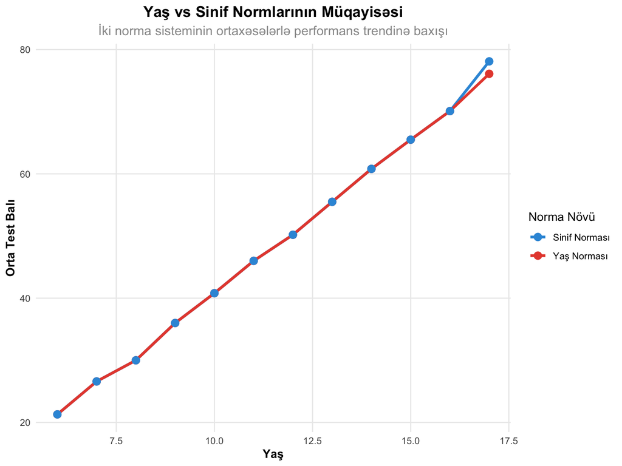

```r
# Norma növlərinin müqayisəsi
norm_comparison_long <- norm_comparison %>%
  select(Yaş, Orta_Yaş, Orta_Sinif) %>%
  pivot_longer(cols = c(Orta_Yaş, Orta_Sinif),
               names_to = "Norma_Növü", values_to = "Orta_Bal") %>%
  mutate(Norma_Növü = ifelse(Norma_Növü == "Orta_Yaş", "Yaş Norması", "Sinif Norması"))

ggplot(norm_comparison_long, aes(x = Yaş, y = Orta_Bal, color = Norma_Növü)) +
  geom_line(size = 1.2) +
  geom_point(size = 3) +
  scale_color_manual(values = colors_basic[1:2]) +
  labs(title = "Yaş vs Sinif Normlarının Müqayisəsi",
       subtitle = "İki norma sisteminin ortaxəsələrlə performans trendinə baxışı",
       x = "Yaş", y = "Orta Test Balı", color = "Norma Növü") +
  theme_clean()
```

```r
# Norma seçimi üçün tövsiyələr
norm_selection_guide <- data.frame(
  Məqsəd = c("İnkişaf qiymətləndirməsi", "Akademik qiymətləndirmə", "Təhsil planlaması",
             "Müqayisəli analiz", "Proqnoz", "İntervensiya"),
  Tövsiyə_Norma = c("Yaş norması", "Sinif norması", "Sinif norması",
                    "Yaş norması", "Yaş norması", "Sinif norması"),
  Səbəb = c("Bioloji inkişaf", "Kurrikulum əsaslı", "Təhsil məzmunu",
            "Həmyaşıdlarla", "İnkişaf trendin", "Akademik məzmun"),
  Nümunə_Sual = c("Yaşına uyğun inkişaf?", "Sinif standartına uyğun?", "Hansı səviyyə?",
                  "Həmyaşıdları ilə necə?", "Gələcək nə gözlənir?", "Hansı dəstək lazım?")
)

kable(norm_selection_guide, caption = "Norma Seçimi üçün Tövsiyə Rəhbəri")
```

Norma Seçimi üçün Tövsiyə Rəhbəri

| Məqsəd | Tövsiyə_Norma | Səbəb | Nümunə_Sual |
| --- | --- | --- | --- |
| İnkişaf qiymətləndirməsi | Yaş norması | Bioloji inkişaf | Yaşına uyğun inkişaf? |
| Akademik qiymətləndirmə | Sinif norması | Kurrikulum əsaslı | Sinif standartına uyğun? |
| Təhsil planlaması | Sinif norması | Təhsil məzmunu | Hansı səviyyə? |
| Müqayisəli analiz | Yaş norması | Həmyaşıdlarla | Həmyaşıdları ilə necə? |
| Proqnoz | Yaş norması | İnkişaf trendin | Gələcək nə gözlənir? |
| İntervensiya | Sinif norması | Akademik məzmun | Hansı dəstək lazım? |

# 4 Standartlaşma Prosesi

## 4.1 Standartlaşmanın Mərhələləri

```r
# Standartlaşma prosesinin mərhələləri
standardization_steps <- data.frame(
  Mərhələ = c("1. Planlama", "2. Nümunə Dizaynı", "3. Məlumat Toplama",
              "4. Keyfiyyət Nəzarəti", "5. Statistik Analiz", "6. Norma Yaradılması"),
  Fəaliyyət = c("Məqsəd təyini, resurs planı", "Örnəkləmə strategiyası",
                "Test tətbiqi, məlumat qeydiyyatı", "Məlumat yoxlanması",
                "Statistik hesablamalar", "Norma cədvəlləri"),
  Çıxış = c("Layihə sənədi", "Örnəkləmə planı", "Xam məlumatlar",
            "Təmizlənmiş məlumatlar", "Statistik nəticələr", "Norma cədvəlləri"),
  Keyfiyyət_Göstəricisi = c("Plan tamlığı", "Reprezentativlik", "Məlumat keyfiyyəti",
                            "Səhv məlumat faizi", "Statistik etibarlılıq", "İstifadə yararlılığı")
)

kable(standardization_steps, caption = "Standartlaşma Prosesinin Mərhələləri")
```

Standartlaşma Prosesinin Mərhələləri

| Mərhələ | Fəaliyyət | Çıxış | Keyfiyyət_Göstəricisi |
| --- | --- | --- | --- |
| 1. Planlama | Məqsəd təyini, resurs planı | Layihə sənədi | Plan tamlığı |
| 2. Nümunə Dizaynı | Örnəkləmə strategiyası | Örnəkləmə planı | Reprezentativlik |
| 3. Məlumat Toplama | Test tətbiqi, məlumat qeydiyyatı | Xam məlumatlar | Məlumat keyfiyyəti |
| 4. Keyfiyyət Nəzarəti | Məlumat yoxlanması | Təmizlənmiş məlumatlar | Səhv məlumat faizi |
| 5. Statistik Analiz | Statistik hesablamalar | Statistik nəticələr | Statistik etibarlılıq |
| 6. Norma Yaradılması | Norma cədvəlləri | Norma cədvəlləri | İstifadə yararlılığı |

```r
# Test kondisiyalarının standartlaşdırılması
test_conditions <- data.frame(
  Aspekt = c("Test Materialları", "Vaxt Məhdudiyyəti", "Fiziki Şərait",
             "İnstruktor Təlimi", "Qiymətləndirmə", "Məlumat Qeydiyyatı"),
  Standart_Tələb = c("Eyni test forması", "Dəqiq vaxt kontrolu", "Uyğun mühit",
                     "Sertifikatlı təlimçi", "Obyektiv sistem", "Real vaxt qeydiyyat"),
  Kontrol_Tədbirləri = c("Material yoxlanması", "Vaxtölçən cihazlar", "Şərait qiymətləndirməsi",
                     "Təlimçi sertifikatı", "İkili qiymətləndirmə", "Avtomatik sistem"),
  Keyfiyyət_Təminatı = c("Random yoxlama", "±30 saniyə dəqiqlik", "Standardlara uyğunluq",
                        "Müntəzəm yenilənmə", "Inter-rater etibarlılıq", "Məlumat bütövlüyü")
)

kable(test_conditions, caption = "Test Şəraitlərinin Standartlaşdırılması")
```

Test Şəraitlərinin Standartlaşdırılması

| Aspekt | Standart_Tələb | Kontrol_Tədbirləri | Keyfiyyət_Təminatı |
| --- | --- | --- | --- |
| Test Materialları | Eyni test forması | Material yoxlanması | Random yoxlama |
| Vaxt Məhdudiyyəti | Dəqiq vaxt kontrolu | Vaxtölçən cihazlar | ±30 saniyə dəqiqlik |
| Fiziki Şərait | Uyğun mühit | Şərait qiymətləndirməsi | Standardlara uyğunluq |
| İnstruktor Təlimi | Sertifikatlı təlimçi | Təlimçi sertifikatı | Müntəzəm yenilənmə |
| Qiymətləndirmə | Obyektiv sistem | İkili qiymətləndirmə | Inter-rater etibarlılıq |
| Məlumat Qeydiyyatı | Real vaxt qeydiyyat | Avtomatik sistem | Məlumat bütövlüyü |

```r
# Norma toplama dizaynı
norm_collection_design <- function(target_population, sample_size, stratification_vars) {

  # Təbəqələnmiş örnəkləmə planı
  design_plan <- data.frame(
    Mərhələ = c("Populyasiya Təyini", "Təbəqələşdirmə", "Ölçü Hesablaması",
                "Ərazilər Seçimi", "Məktəblər Seçimi", "Tələbələr Seçimi"),
    Təsvir = c("Hədəf qrupun dəqiq müəyyənləşdirilməsi",
               "Demografik və coğrafi təbəqələr",
               "Statistik güc analizi əsasında",
               "Regional reprezentativlik",
               "Məktəb tiplərinin nəzərə alınması",
               "Təsadüfi seçim təbəqələr daxilində"),
    Nəticə = c("Populyasiya parametrləri", "Təbəqə cədvəli",
               "Minimum nümunə ölçüsü", "Seçilmiş ərazilər",
               "İştirakçı məktəblər", "Final nümunə")
  )

  return(design_plan)
}

# Nümunə norma dizaynı
sample_design <- norm_collection_design("6-18 yaş", 2000, c("Yaş", "Cinsiyyət", "Region"))
kable(sample_design, caption = "Norma Toplama Dizaynı")
```

Norma Toplama Dizaynı

| Mərhələ | Təsvir | Nəticə |
| --- | --- | --- |
| Populyasiya Təyini | Hədəf qrupun dəqiq müəyyənləşdirilməsi | Populyasiya parametrləri |
| Təbəqələşdirmə | Demografik və coğrafi təbəqələr | Təbəqə cədvəli |
| Ölçü Hesablaması | Statistik güc analizi əsasında | Minimum nümunə ölçüsü |
| Ərazilər Seçimi | Regional reprezentativlik | Seçilmiş ərazilər |
| Məktəblər Seçimi | Məktəb tiplərinin nəzərə alınması | İştirakçı məktəblər |
| Tələbələr Seçimi | Təsadüfi seçim təbəqələr daxilində | Final nümunə |

```r
# Məlumat keyfiyyəti yoxlaması
data_quality_check <- function(raw_data) {

  quality_metrics <- data.frame(
    Göstərici = c("Buraxılmış məlumat %", "Kənar qiymətlər %", "Təsadüfi cavab %",
                  "Minimum vaxt %", "Maksimum vaxt %", "Şübhəli nümunələr %"),
    Hesablama = c("sum(is.na())/length()", "IQR metoduna görə", "Təsadüfi seçim testi",
                  "< 10 dəqiqə", "> 2 saat", "Kombinə şübhə göstəricisi"),
    Maksimum_Məqbul = c("5%", "2%", "1%", "3%", "1%", "2%"),
    Tədbir = c("İmputation/çıxarma", "Araşdırma/çıxarma", "Çıxarma",
               "Validasiya/çıxarma", "Validasiya/çıxarma", "Araşdırma/çıxarma")
  )

  return(quality_metrics)
}

quality_check_table <- data_quality_check(test_performance)
kable(quality_check_table, caption = "Məlumat Keyfiyyəti Yoxlaması")
```

Məlumat Keyfiyyəti Yoxlaması

| Göstərici | Hesablama | Maksimum_Məqbul | Tədbir |
| --- | --- | --- | --- |
| Buraxılmış məlumat % | sum(is.na())/length() | 5% | İmputation/çıxarma |
| Kənar qiymətlər % | IQR metoduna görə | 2% | Araşdırma/çıxarma |
| Təsadüfi cavab % | Təsadüfi seçim testi | 1% | Çıxarma |
| Minimum vaxt % | < 10 dəqiqə | 3% | Validasiya/çıxarma |
| Maksimum vaxt % | > 2 saat | 1% | Validasiya/çıxarma |
| Şübhəli nümunələr % | Kombinə şübhə göstəricisi | 2% | Araşdırma/çıxarma |

## 4.2 Norma Cədvəllərinin Yaradılması

```r
# Hərtərəfli norma cədvəli yaradma funksiyası
create_comprehensive_norm_table <- function(data, score_col, group_col) {

  norm_table <- data %>%
    group_by(!!sym(group_col)) %>%
    summarise(
      N = n(),
      Orta = round(mean(!!sym(score_col), na.rm = TRUE), 1),
      SD = round(sd(!!sym(score_col), na.rm = TRUE), 1),
      Min = round(min(!!sym(score_col), na.rm = TRUE), 1),
      Max = round(max(!!sym(score_col), na.rm = TRUE), 1),
      P05 = round(quantile(!!sym(score_col), 0.05, na.rm = TRUE), 1),
      P10 = round(quantile(!!sym(score_col), 0.10, na.rm = TRUE), 1),
      P25 = round(quantile(!!sym(score_col), 0.25, na.rm = TRUE), 1),
      P50 = round(quantile(!!sym(score_col), 0.50, na.rm = TRUE), 1),
      P75 = round(quantile(!!sym(score_col), 0.75, na.rm = TRUE), 1),
      P90 = round(quantile(!!sym(score_col), 0.90, na.rm = TRUE), 1),
      P95 = round(quantile(!!sym(score_col), 0.95, na.rm = TRUE), 1),
      .groups = 'drop'
    ) %>%
    mutate(
      # T-bal parametrləri
      T_Orta = 50,
      T_SD = 10,
      # Stanin sərhədləri
      Stanine_1 = round(Orta - 1.75 * SD, 1),
      Stanine_9 = round(Orta + 1.75 * SD, 1)
    )

  return(norm_table)
}

# Yaş üçün hərtərəfli norma cədvəli
comprehensive_age_norms <- create_comprehensive_norm_table(test_performance, "Test_Score", "Yaş")
kable(head(comprehensive_age_norms, 8), caption = "Hərtərəfli Yaş Norma Cədvəli")
```

Hərtərəfli Yaş Norma Cədvəli

| Yaş | N | Orta | SD | Min | Max | P05 | P10 | P25 | P50 | P75 | P90 | P95 | T_Orta | T_SD | Stanine_1 | Stanine_9 |
| --- | --- | --- | --- | --- | --- | --- | --- | --- | --- | --- | --- | --- | --- | --- | --- | --- |
| 6 | 1000 | 21.3 | 11.3 | 0.0 | 57.1 | 2.1 | 6.0 | 13.0 | 21.4 | 29.1 | 35.4 | 40.1 | 50 | 10 | 1.5 | 41.1 |
| 7 | 1000 | 26.6 | 11.8 | 0.0 | 62.2 | 6.8 | 11.8 | 18.7 | 26.3 | 34.5 | 41.7 | 46.0 | 50 | 10 | 5.9 | 47.2 |
| 8 | 1000 | 30.0 | 11.1 | 0.0 | 77.2 | 11.5 | 15.6 | 23.1 | 29.8 | 37.4 | 44.2 | 48.1 | 50 | 10 | 10.6 | 49.4 |
| 9 | 1000 | 36.0 | 11.5 | 0.0 | 76.4 | 17.7 | 21.5 | 28.0 | 35.6 | 43.9 | 51.4 | 55.4 | 50 | 10 | 15.9 | 56.1 |
| 10 | 1000 | 40.8 | 11.5 | 6.2 | 77.0 | 21.7 | 26.2 | 32.8 | 40.8 | 48.8 | 55.6 | 60.1 | 50 | 10 | 20.7 | 60.9 |
| 11 | 1000 | 46.0 | 12.1 | 7.8 | 87.3 | 25.7 | 30.1 | 37.6 | 46.4 | 54.3 | 60.7 | 66.0 | 50 | 10 | 24.8 | 67.2 |
| 12 | 1000 | 50.2 | 11.6 | 12.9 | 93.9 | 31.2 | 35.7 | 42.5 | 49.9 | 57.8 | 64.9 | 69.4 | 50 | 10 | 29.9 | 70.5 |
| 13 | 1000 | 55.5 | 12.0 | 16.9 | 99.1 | 36.8 | 40.3 | 47.4 | 55.6 | 63.7 | 71.0 | 75.8 | 50 | 10 | 34.5 | 76.5 |

```r
# Bal çevrilmə cədvəli yaradılması
create_score_conversion_table <- function(raw_score_range, mean_score, sd_score) {

  raw_scores <- seq(raw_score_range[1], raw_score_range[2], by = 5)

  conversion_table <- data.frame(
    Xam_Bal = raw_scores,
    Z_Bal = round((raw_scores - mean_score) / sd_score, 2),
    T_Bal = round(50 + 10 * (raw_scores - mean_score) / sd_score, 0),
    Percentil = round(pnorm((raw_scores - mean_score) / sd_score) * 100, 0)
  ) %>%
    mutate(
      Stanine = case_when(
        Z_Bal < -1.75 ~ 1,
        Z_Bal < -1.25 ~ 2,
        Z_Bal < -0.75 ~ 3,
        Z_Bal < -0.25 ~ 4,
        Z_Bal < 0.25 ~ 5,
        Z_Bal < 0.75 ~ 6,
        Z_Bal < 1.25 ~ 7,
        Z_Bal < 1.75 ~ 8,
        TRUE ~ 9
      ),
      İnterpretasiya = case_when(
        Percentil >= 95 ~ "Çox Yüksək",
        Percentil >= 84 ~ "Yüksək",
        Percentil >= 16 ~ "Orta",
        Percentil >= 5 ~ "Aşağı",
        TRUE ~ "Çox Aşağı"
      )
    )

  return(conversion_table)
}

# 12 yaş üçün çevrilmə cədvəli
age_12_stats <- comprehensive_age_norms %>% filter(Yaş == 12)
conversion_12 <- create_score_conversion_table(c(0, 100), age_12_stats$Orta, age_12_stats$SD)
kable(conversion_12, caption = "12 Yaş üçün Bal Çevrilmə Cədvəli")
```

12 Yaş üçün Bal Çevrilmə Cədvəli

| Xam_Bal | Z_Bal | T_Bal | Percentil | Stanine | İnterpretasiya |
| --- | --- | --- | --- | --- | --- |
| 0 | -4.33 | 7 | 0 | 1 | Çox Aşağı |
| 5 | -3.90 | 11 | 0 | 1 | Çox Aşağı |
| 10 | -3.47 | 15 | 0 | 1 | Çox Aşağı |
| 15 | -3.03 | 20 | 0 | 1 | Çox Aşağı |
| 20 | -2.60 | 24 | 0 | 1 | Çox Aşağı |
| 25 | -2.17 | 28 | 1 | 1 | Çox Aşağı |
| 30 | -1.74 | 33 | 4 | 2 | Çox Aşağı |
| 35 | -1.31 | 37 | 10 | 2 | Aşağı |
| 40 | -0.88 | 41 | 19 | 3 | Orta |
| 45 | -0.45 | 46 | 33 | 4 | Orta |
| 50 | -0.02 | 50 | 49 | 5 | Orta |
| 55 | 0.41 | 54 | 66 | 6 | Orta |
| 60 | 0.84 | 58 | 80 | 7 | Orta |
| 65 | 1.28 | 63 | 90 | 8 | Yüksək |
| 70 | 1.71 | 67 | 96 | 8 | Çox Yüksək |
| 75 | 2.14 | 71 | 98 | 9 | Çox Yüksək |
| 80 | 2.57 | 76 | 99 | 9 | Çox Yüksək |
| 85 | 3.00 | 80 | 100 | 9 | Çox Yüksək |
| 90 | 3.43 | 84 | 100 | 9 | Çox Yüksək |
| 95 | 3.86 | 89 | 100 | 9 | Çox Yüksək |
| 100 | 4.29 | 93 | 100 | 9 | Çox Yüksək |

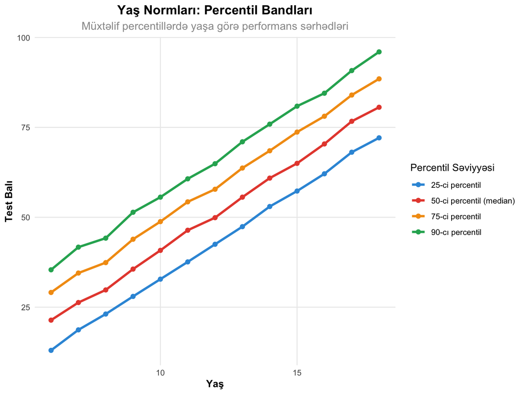

```r
# Norma cədvəllərinin vizual təqdimatı
norm_visualization_data <- comprehensive_age_norms %>%
  select(Yaş, P25, P50, P75, P90) %>%
  pivot_longer(cols = c(P25, P50, P75, P90), names_to = "Percentil", values_to = "Bal")

ggplot(norm_visualization_data, aes(x = Yaş, y = Bal, color = Percentil)) +
  geom_line(size = 1.2) +
  geom_point(size = 2) +
  scale_color_manual(values = colors_basic[1:4],
                     labels = c("25-ci percentil", "50-ci percentil (median)",
                               "75-ci percentil", "90-cı percentil")) +
  labs(title = "Yaş Normları: Percentil Bandları",
       subtitle = "Müxtəlif percentillərdə yaşa görə performans sərhədləri",
       x = "Yaş", y = "Test Balı", color = "Percentil Səviyyəsi") +
  theme_clean()
```

```r
# Norma interpretasiya rəhbəri
interpretation_guide <- data.frame(
  Percentil_Aralığı = c("95-99", "84-94", "16-83", "5-15", "1-4"),
  Stanine = c("8-9", "7", "4-6", "3", "1-2"),
  T_Bal_Aralığı = c("67+", "57-66", "40-56", "30-39", "<30"),
  İnterpretasiya = c("Çox Yüksək", "Yüksək", "Orta Aralıq", "Aşağı", "Çox Aşağı"),
  Praktik_Mənası = c("Üstün performans", "Ortadan yuxarı", "Normal aralıq",
                     "Dəstəyə ehtiyac", "Intensiv müdaxilə"),
  Təxmini_Faiz = c("4%", "13%", "68%", "13%", "2%")
)

kable(interpretation_guide, caption = "Norma İnterpretasiya Rəhbəri")
```

Norma İnterpretasiya Rəhbəri

| Percentil_Aralığı | Stanine | T_Bal_Aralığı | İnterpretasiya | Praktik_Mənası | Təxmini_Faiz |
| --- | --- | --- | --- | --- | --- |
| 95-99 | 8-9 | 67+ | Çox Yüksək | Üstün performans | 4% |
| 84-94 | 7 | 57-66 | Yüksək | Ortadan yuxarı | 13% |
| 16-83 | 4-6 | 40-56 | Orta Aralıq | Normal aralıq | 68% |
| 5-15 | 3 | 30-39 | Aşağı | Dəstəyə ehtiyac | 13% |
| 1-4 | 1-2 | <30 | Çox Aşağı | Intensiv müdaxilə | 2% |

# 5 R Kodları: Norma Cədvəllərinin Yaradılması

## 5.1 Universal Norma Yaradıcısı

```r
# Universal norma funksiyalar paketi
NormCreator <- list(

  # Əsas norma yaradıcısı
  create_norms = function(data, score_cols, grouping_vars = NULL,
                         percentiles = c(5, 10, 25, 50, 75, 90, 95)) {

    if(is.null(grouping_vars)) {
      # Ümumi normalar
      result <- data %>%
        summarise(
          across(all_of(score_cols),
                 list(
                   N = ~ sum(!is.na(.)),
                   Mean = ~ round(mean(., na.rm = TRUE), 2),
                   SD = ~ round(sd(., na.rm = TRUE), 2),
                   Min = ~ round(min(., na.rm = TRUE), 1),
                   Max = ~ round(max(., na.rm = TRUE), 1)
                 ),
                 .names = "{.col}_{.fn}"),
          .groups = 'drop'
        )

      # Percentillər əlavə et
      for(col in score_cols) {
        for(p in percentiles) {
          col_name <- paste0(col, "_P", p)
          result[[col_name]] <- round(quantile(data[[col]], p/100, na.rm = TRUE), 1)
        }
      }

    } else {
      # Qrup əsaslı normalar
      result <- data %>%
        group_by(across(all_of(grouping_vars))) %>%
        summarise(
          across(all_of(score_cols),
                 list(
                   N = ~ sum(!is.na(.)),
                   Mean = ~ round(mean(., na.rm = TRUE), 2),
                   SD = ~ round(sd(., na.rm = TRUE), 2),
                   Min = ~ round(min(., na.rm = TRUE), 1),
                   Max = ~ round(max(., na.rm = TRUE), 1)
                 ),
                 .names = "{.col}_{.fn}"),
          .groups = 'drop'
        )

      # Percentillər əlavə et
      for(col in score_cols) {
        for(p in percentiles) {
          col_name <- paste0(col, "_P", p)
          result[[col_name]] <- data %>%
            group_by(across(all_of(grouping_vars))) %>%
            summarise(!!col_name := round(quantile(!!sym(col), p/100, na.rm = TRUE), 1),
                     .groups = 'drop') %>%
            pull(!!col_name)
        }
      }
    }

    return(result)
  },

  # Bal çevrilmə cədvəli
  create_conversion_table = function(reference_mean, reference_sd,
                                   score_range = c(0, 100), by = 5) {

    raw_scores <- seq(score_range[1], score_range[2], by = by)

    data.frame(
      Xam_Bal = raw_scores,
      Z_Bal = round((raw_scores - reference_mean) / reference_sd, 2),
      T_Bal = round(50 + 10 * (raw_scores - reference_mean) / reference_sd, 0),
      Percentil = round(pnorm((raw_scores - reference_mean) / reference_sd) * 100, 0),
      Stanine = cut((raw_scores - reference_mean) / reference_sd,
                   breaks = c(-Inf, -1.75, -1.25, -0.75, -0.25, 0.25, 0.75, 1.25, 1.75, Inf),
                   labels = 1:9, include.lowest = TRUE) %>% as.numeric()
    )
  },

  # Norma tətbiqi
  apply_norms = function(new_scores, norm_table, score_col, group_col = NULL, group_value = NULL) {

    if(!is.null(group_col) && !is.null(group_value)) {
      reference_stats <- norm_table %>%
        filter(!!sym(group_col) == group_value)
    } else {
      reference_stats <- norm_table
    }

    ref_mean <- reference_stats[[paste0(score_col, "_Mean")]][1]
    ref_sd <- reference_stats[[paste0(score_col, "_SD")]][1]

    z_scores <- (new_scores - ref_mean) / ref_sd

    data.frame(
      Xam_Bal = new_scores,
      Z_Bal = round(z_scores, 2),
      T_Bal = round(50 + 10 * z_scores, 0),
      Percentil = round(pnorm(z_scores) * 100, 0),
      Stanine = cut(z_scores,
                   breaks = c(-Inf, -1.75, -1.25, -0.75, -0.25, 0.25, 0.75, 1.25, 1.75, Inf),
                   labels = 1:9, include.lowest = TRUE) %>% as.numeric()
    )
  }
)

# Nümunə istifadə
sample_test_data <- data.frame(
  Student_ID = 1:200,
  Age = sample(10:16, 200, replace = TRUE),
  Gender = sample(c("Male", "Female"), 200, replace = TRUE),
  Math_Score = round(rnorm(200, 70, 15), 1),
  Reading_Score = round(rnorm(200, 65, 12), 1)
)

# Yaş əsaslı normalar yaradılması
age_based_norms <- NormCreator$create_norms(
  data = sample_test_data,
  score_cols = c("Math_Score", "Reading_Score"),
  grouping_vars = "Age"
)

kable(head(age_based_norms, 6), caption = "Yaş Əsaslı Norma Cədvəli (NormCreator ilə)")
```

Yaş Əsaslı Norma Cədvəli (NormCreator ilə)

| Age | Math_Score_N | Math_Score_Mean | Math_Score_SD | Math_Score_Min | Math_Score_Max | Reading_Score_N | Reading_Score_Mean | Reading_Score_SD | Reading_Score_Min | Reading_Score_Max | Math_Score_P5 | Math_Score_P10 | Math_Score_P25 | Math_Score_P50 | Math_Score_P75 | Math_Score_P90 | Math_Score_P95 | Reading_Score_P5 | Reading_Score_P10 | Reading_Score_P25 | Reading_Score_P50 | Reading_Score_P75 | Reading_Score_P90 | Reading_Score_P95 |
| --- | --- | --- | --- | --- | --- | --- | --- | --- | --- | --- | --- | --- | --- | --- | --- | --- | --- | --- | --- | --- | --- | --- | --- | --- |
| 10 | 26 | 71.46 | 14.93 | 48.2 | 97.8 | 26 | 68.57 | 12.31 | 40.3 | 89.7 | 52.3 | 54.4 | 57.3 | 71.0 | 83.5 | 92.2 | 95.0 | 51.8 | 55.8 | 59.7 | 68.1 | 78.0 | 84.3 | 86.4 |
| 11 | 24 | 71.20 | 14.09 | 32.9 | 93.2 | 24 | 65.40 | 15.28 | 27.1 | 86.0 | 49.5 | 57.6 | 64.0 | 71.0 | 81.7 | 88.6 | 91.5 | 43.5 | 47.7 | 57.1 | 68.8 | 76.0 | 83.1 | 85.2 |
| 12 | 37 | 72.78 | 13.23 | 46.2 | 101.4 | 37 | 68.95 | 9.37 | 49.5 | 89.8 | 53.5 | 56.7 | 61.5 | 72.5 | 82.2 | 89.8 | 93.9 | 52.0 | 56.7 | 64.1 | 70.3 | 73.4 | 80.7 | 83.5 |
| 13 | 32 | 66.49 | 15.30 | 39.8 | 96.6 | 32 | 63.51 | 11.24 | 46.5 | 87.7 | 41.8 | 47.4 | 52.7 | 69.8 | 77.5 | 86.0 | 87.2 | 48.0 | 49.8 | 54.6 | 62.8 | 71.0 | 77.5 | 83.6 |
| 14 | 26 | 66.80 | 20.50 | 25.2 | 103.4 | 26 | 65.72 | 10.09 | 48.7 | 90.8 | 42.4 | 42.7 | 49.4 | 72.4 | 80.8 | 92.3 | 94.0 | 52.0 | 53.9 | 57.8 | 65.8 | 70.6 | 77.4 | 80.4 |
| 15 | 33 | 68.20 | 14.71 | 42.9 | 101.6 | 33 | 66.62 | 12.27 | 41.7 | 89.1 | 47.6 | 49.3 | 56.3 | 68.2 | 78.5 | 86.0 | 89.9 | 49.7 | 52.8 | 55.8 | 66.7 | 77.6 | 82.6 | 84.0 |

```r
# Çevrilmə cədvəli yaradılması
math_conversion <- NormCreator$create_conversion_table(
  reference_mean = 70,
  reference_sd = 15,
  score_range = c(20, 100),
  by = 5
)

kable(head(math_conversion, 10), caption = "Riyaziyyat üçün Bal Çevrilmə Cədvəli")
```

Riyaziyyat üçün Bal Çevrilmə Cədvəli

| Xam_Bal | Z_Bal | T_Bal | Percentil | Stanine |
| --- | --- | --- | --- | --- |
| 20 | -3.33 | 17 | 0 | 1 |
| 25 | -3.00 | 20 | 0 | 1 |
| 30 | -2.67 | 23 | 0 | 1 |
| 35 | -2.33 | 27 | 1 | 1 |
| 40 | -2.00 | 30 | 2 | 1 |
| 45 | -1.67 | 33 | 5 | 2 |
| 50 | -1.33 | 37 | 9 | 2 |
| 55 | -1.00 | 40 | 16 | 3 |
| 60 | -0.67 | 43 | 25 | 4 |
| 65 | -0.33 | 47 | 37 | 4 |

```r
# Yeni tələbələr üçün normların tətbiqi
new_student_scores <- c(85, 72, 68, 91, 55)
new_student_norms <- NormCreator$apply_norms(
  new_scores = new_student_scores,
  norm_table = age_based_norms,
  score_col = "Math_Score",
  group_col = "Age",
  group_value = 12
)

kable(new_student_norms, caption = "Yeni Tələbələr üçün Norma Tətbiqi")
```

Yeni Tələbələr üçün Norma Tətbiqi

| Xam_Bal | Z_Bal | T_Bal | Percentil | Stanine |
| --- | --- | --- | --- | --- |
| 85 | 0.92 | 59 | 82 | 7 |
| 72 | -0.06 | 49 | 48 | 5 |
| 68 | -0.36 | 46 | 36 | 4 |
| 91 | 1.38 | 64 | 92 | 8 |
| 55 | -1.34 | 37 | 9 | 2 |

## 5.2 Avtomatik Hesabat Generatoru

```r
# Norma hesabat generatoru
generate_norm_report <- function(data, score_cols, group_var, report_title = "Norma Analizi") {

  cat("\n", "="*50, "\n")
  cat(report_title, "\n")
  cat("="*50, "\n\n")

  # Ümumi statistikalar
  cat("ÜMUMI STATİSTİKALAR\n")
  cat("-"*30, "\n")

  overall_stats <- data %>%
    summarise(
      across(all_of(score_cols),
             list(N = ~ sum(!is.na(.)),
                  Mean = ~ round(mean(., na.rm = TRUE), 2),
                  SD = ~ round(sd(., na.rm = TRUE), 2)),
             .names = "{.col}_{.fn}")
    )

  print(overall_stats)

  cat("\n\nQRUP STATİSTİKALARI\n")
  cat("-"*30, "\n")

  # Qrup statistikaları
  group_stats <- NormCreator$create_norms(data, score_cols, group_var)
  print(group_stats)

  # Vizual təqdimat üçün məlumat hazırlığı
  viz_data <- data %>%
    select(all_of(c(group_var, score_cols))) %>%
    pivot_longer(cols = all_of(score_cols), names_to = "Test", values_to = "Score")

  # Box plot
  p1 <- ggplot(viz_data, aes(x = factor(!!sym(group_var)), y = Score, fill = Test)) +
    geom_boxplot(alpha = 0.7) +
    facet_wrap(~Test, scales = "free_y") +
    scale_fill_manual(values = colors_basic[1:length(score_cols)]) +
    labs(title = paste("Qrup üzrə Performans Paylanması -", report_title),
         x = group_var, y = "Test Balı") +
    theme_clean() +
    theme(legend.position = "none")

  print(p1)

  # Trend xətti
  trend_data <- group_stats %>%
    select(all_of(group_var), ends_with("_Mean")) %>%
    pivot_longer(cols = ends_with("_Mean"), names_to = "Test", values_to = "Mean_Score") %>%
    mutate(Test = gsub("_Mean", "", Test))

  p2 <- ggplot(trend_data, aes(x = !!sym(group_var), y = Mean_Score, color = Test)) +
    geom_line(size = 1.2) +
    geom_point(size = 3) +
    scale_color_manual(values = colors_basic[1:length(score_cols)]) +
    labs(title = paste("Qrup üzrə Orta Performans Trendi -", report_title),
         x = group_var, y = "Orta Bal", color = "Test") +
    theme_clean()

  print(p2)

  cat("\n\nHESABAT TARİXİ:", as.character(Sys.Date()), "\n")
  cat("="*50, "\n")

  return(list(overall = overall_stats, group = group_stats, plots = list(p1, p2)))
}

# Hesabat generasiyası
# norm_report <- generate_norm_report(
#   data = sample_test_data,
#   score_cols = c("Math_Score", "Reading_Score"),
#   group_var = "Age",
#   report_title = "Yaş Əsaslı Norma Analizi"
# )

# Keyfiyyət yoxlaması funksiyası
quality_check_norms <- function(norm_table, min_n = 30, max_cv = 0.3) {

  quality_results <- norm_table %>%
    mutate(
      across(ends_with("_N"), ~ . >= min_n, .names = "Adequate_{.col}"),
      across(ends_with("_Mean"), ~ abs(.) > 0, .names = "Valid_{.col}")
    )

  # CV hesablaması
  mean_cols <- names(norm_table)[grepl("_Mean$", names(norm_table))]
  sd_cols <- names(norm_table)[grepl("_SD$", names(norm_table))]

  for(i in seq_along(mean_cols)) {
    cv_col <- paste0("CV_", gsub("_Mean", "", mean_cols[i]))
    quality_results[[cv_col]] <- round(norm_table[[sd_cols[i]]] / norm_table[[mean_cols[i]]], 3)
  }

  # Keyfiyyət bayraqları
  quality_flags <- quality_results %>%
    select(starts_with("Adequate_"), starts_with("CV_")) %>%
    mutate(
      across(starts_with("CV_"), ~ . <= max_cv, .names = "Good_{.col}"),
      Quality_Flag = rowMeans(select(., starts_with("Adequate_"), starts_with("Good_"))) >= 0.8
    )

  return(list(
    detailed = quality_results,
    flags = quality_flags,
    summary = data.frame(
      Total_Groups = nrow(norm_table),
      Good_Quality = sum(quality_flags$Quality_Flag),
      Quality_Rate = round(mean(quality_flags$Quality_Flag) * 100, 1)
    )
  ))
}

# Keyfiyyət yoxlaması
quality_check_results <- quality_check_norms(age_based_norms)
kable(quality_check_results$summary, caption = "Norma Keyfiyyət Yoxlaması Xülasəsi")
```

Norma Keyfiyyət Yoxlaması Xülasəsi

| Total_Groups | Good_Quality | Quality_Rate |
| --- | --- | --- |
| 7 | 3 | 42.9 |

```r
# Norma tətbiq funksiyası
apply_norms_to_new_data <- function(new_data, norm_table, score_col, group_col, group_value) {

  # Referans statistikalarını tap
  ref_stats <- norm_table %>%
    filter(!!sym(group_col) == group_value)

  if(nrow(ref_stats) == 0) {
    warning(paste("Qrup", group_value, "üçün norma tapılmadı"))
    return(NULL)
  }

  mean_col <- paste0(score_col, "_Mean")
  sd_col <- paste0(score_col, "_SD")

  ref_mean <- ref_stats[[mean_col]]
  ref_sd <- ref_stats[[sd_col]]

  # Çevrilmə
  new_data %>%
    mutate(
      Z_Score = round((!!sym(score_col) - ref_mean) / ref_sd, 2),
      T_Score = round(50 + 10 * Z_Score, 0),
      Percentile = round(pnorm(Z_Score) * 100, 0),
      Stanine = cut(Z_Score,
                   breaks = c(-Inf, -1.75, -1.25, -0.75, -0.25, 0.25, 0.75, 1.25, 1.75, Inf),
                   labels = 1:9, include.lowest = TRUE) %>% as.numeric(),
      Interpretation = case_when(
        Percentile >= 95 ~ "Çox Yüksək",
        Percentile >= 84 ~ "Yüksək",
        Percentile >= 16 ~ "Orta",
        Percentile >= 5 ~ "Aşağı",
        TRUE ~ "Çox Aşağı"
      ),
      Reference_Group = group_value,
      Reference_Mean = ref_mean,
      Reference_SD = ref_sd
    )
}

# Yeni məlumatlar üçün tətbiq
new_test_data <- data.frame(
  Student_ID = c("S001", "S002", "S003"),
  Age = c(12, 12, 12),
  Math_Score = c(85, 62, 78)
)

applied_norms <- apply_norms_to_new_data(
  new_data = new_test_data,
  norm_table = age_based_norms,
  score_col = "Math_Score",
  group_col = "Age",
  group_value = 12
)

kable(applied_norms, caption = "Yeni Məlumatlara Norma Tətbiqi")
```

Yeni Məlumatlara Norma Tətbiqi

| Student_ID | Age | Math_Score | Z_Score | T_Score | Percentile | Stanine | Interpretation | Reference_Group | Reference_Mean | Reference_SD |
| --- | --- | --- | --- | --- | --- | --- | --- | --- | --- | --- |
| S001 | 12 | 85 | 0.92 | 59 | 82 | 7 | Orta | 12 | 72.78 | 13.23 |
| S002 | 12 | 62 | -0.81 | 42 | 21 | 3 | Orta | 12 | 72.78 | 13.23 |
| S003 | 12 | 78 | 0.39 | 54 | 65 | 6 | Orta | 12 | 72.78 | 13.23 |

# 6 Tapşırıq: Yaş Qrupları üçün Norma Cədvəlləri

## 6.1 Praktik Tapşırıq (50 xal)

```r
# VERİLMİŞ MƏLUMATLAR
set.seed(sizin_tələbə_nömrəniz) # Öz nömrənizi yazın

# 500 tələbə üçün simulyasiya
n_students <- 500

homework_data <- data.frame(
  Student_ID = paste0("T", sprintf("%03d", 1:n_students)),
  Yaş = sample(8:16, n_students, replace = TRUE),
  Cinsiyyət = sample(c("Kişi", "Qadın"), n_students, replace = TRUE),
  Region = sample(c("Şəhər", "Kənd"), n_students, replace = TRUE, prob = c(0.7, 0.3)),

  # Test balları (yaş təsiri ilə)
  Riyaziyyat = round(40 + (rep(8:16, length.out = n_students) - 8) * 3 +
                     rnorm(n_students, 0, 8), 1),
  Dil = round(45 + (rep(8:16, length.out = n_students) - 8) * 2.5 +
              rnorm(n_students, 0, 7), 1),
  Elm = round(50 + (rep(8:16, length.out = n_students) - 8) * 2 +
              rnorm(n_students, 0, 6), 1)
)

# TAPŞİRIQUN HİSSƏLƏRİ:

# 1. TƏSVİRİ STATİSTİKALAR (10 xal)
# - Hər yaş qrupu üçün N, orta, SD hesablayın
# - Ümumi statistikalar cədvəli yaradın
# - Məlumat keyfiyyətini yoxlayın

# 2. NORMA CƏDVƏLLƏRİ (15 xal)
# - Yaş qrupları üçün hərtərəfli norma cədvəli yaradın
# - Percentil qiymətləri daxil edin (5, 10, 25, 50, 75, 90, 95)
# - Minimum 30 tələbə olan yaş qruplarını daxil edin

# 3. BAL ÇEVRİLMƏ CƏDVƏLLƏRİ (10 xal)
# - 12 yaş qrupu üçün Z, T, Stanine, Percentil cədvəli yaradın
# - 0-dan 100-ə qədər 5 vahid intervallarla
# - İnterpretasiya sütunu əlavə edin

# 4. VİZUAL TƏQDİMAT (10 xal)
# - Yaş qrupları üzrə orta performans trendin göstərin
# - Percentil bandlarını (25, 50, 75, 90) çəkin
# - Box plot yaradın

# 5. KEYFİYYƏT QİYMƏTLƏNDİRMƏSİ (5 xal)
# - Hər yaş qrupu üçün keyfiyyət göstəricilər hesablayın
# - Minimum nümunə ölçüsü tələbini yoxlayın
# - Məlumat bütövlük hesabatı verin

# HƏLL STRUKTURU:
print("=== MƏRHƏLƏ 1: TƏSVİRİ STATİSTİKALAR ===")
# Kodunuzu burada yazın

print("=== MƏRHƏLƏ 2: NORMA CƏDVƏLLƏRİ ===")
# Kodunuzu burada yazın

print("=== MƏRHƏLƏ 3: BAL ÇEVRİLMƏ CƏDVƏLLƏRİ ===")
# Kodunuzu burada yazın

print("=== MƏRHƏLƏ 4: VİZUAL TƏQDİMAT ===")
# Kodunuzu burada yazın

print("=== MƏRHƏLƏ 5: KEYFİYYƏT QİYMƏTLƏNDİRMƏSİ ===")
# Kodunuzu burada yazın

# CAVAB FORMATINIZ:
# 1. Hər mərhələ üçün R kodu
# 2. Nəticələrin interpretasiyası
# 3. Keyfiyyət qiymətləndirməsi
# 4. Tövsiyələr

# TƏSLİM TARİXİ: [Təyin ediləcək]
# QEYD: Bütün hesablamaları R-da aparın və nəticələri cədvəl formatında təqdim edin
```

## 6.2 Nəzəri Suallar (25 xal)

**Sual 1 (8 xal):** Norma qruplarının seçimi zamanı həm homojenlik həm də reprezentativlik tələblərini necə balanslaşdırmaq olar? Konkret nümunələrlə izah edin.

**Sual 2 (8 xal):** Yaş normaları ilə sinif normaları arasında hansı hallarda fərq yarana bilər və bu fərqlər necə interpretasiya edilməlidir?

**Sual 3 (9 xal):** Norma cədvəllərinin yenilənməsi üçün hansı kriteriyalar istifadə edilməlidir? “Norma inflasiyası” fenomeni nədir və necə qarşısı alına bilər?

# 7 Dərsin Xülasəsi

## 7.1 Əsas Nəticələr

**Norma Qruplarının Mahiyyəti:** - ✓ **Təyinedici faktorlar** - yaş, sinif, region, cinsiyyət və s. - ✓ **Reprezentativlik** - populyasiyanın düzgün təmsili - ✓ **Kontekst uyğunluğu** - məqsədə uyğun norma seçimi

**Nümunə Seçimi Metodları:** - ✓ **Təsadüfi seçim** - hər vahidin bərabər şansı - ✓ **Təbəqələnmiş seçim** - homojen qruplar daxilində seçim - ✓ **Keyfiyyət kontrolu** - minimum ölçü və reprezentativlik

**Standartlaşma Prosesi:** - ✓ **Mərhələli yanaşma** - planlama, icra, analiz, norma yaradılması - ✓ **Keyfiyyət təminatı** - standart şərait və prosedurlar - ✓ **R avtomatlaşması** - effektiv hesablama və hesabat

# 8 Növbəti Dərslərə Hazırlıq

## 8.1 Dərs 18: “Percentil Ranklar və Test Ekvivalentliği”

Növbəti dərsdə öyrənəcəklər:

- ✓ Percentil rankların dəqiq hesablanması və interpretasiyası
- ✓ Test formalarının ekvivalentlik analizi
- ✓ Linear və qeyri-linear ekvivalentlik metodları
- ✓ Test-retest etibarlılığı və stabillik

## 8.2 Dərs 19: “Adaptiv Testləşmə və CAT Sistemləri”

Sonrakı mövzular:

- ✓ Kompüter Adaptiv Testləşmə (CAT) prinsipləri
- ✓ İtem Response Theory (IRT) əsasları
- ✓ Adaptiv alqoritmlərin dizaynı
- ✓ CAT sistemlərinin effektivlik analizi

# 9 Əlavə Tədqiqat Materialları

## 9.1 Əsas Ədəbiyyat

**Məcburi oxu:** - Angoff, W.H. (1984). *Scales, Norms, and Equivalent Scores*. Educational Testing Service - Kolen, M.J., & Brennan, R.L. (2014). *Test Equating, Scaling, and Linking*. Springer - Crocker, L., & Algina, J. (2008). *Introduction to Classical and Modern Test Theory*. Fəsil 14-15

**Tövsiyə olunan:** - Dorans, N.J., Pommerich, M., & Holland, P.W. (2007). *Linking and Aligning Scores and Scales* - von Davier, A.A. (2011). *Statistical Models for Test Equating, Scaling, and Linking*

## 9.2 Praktik Resurslar

**R Paketləri:** - `base R` - əsas statistik funksiyalar (həmişə mövcud) - `dplyr` və `ggplot2` - məlumat manipulyasiyası və vizuallaşma - `psych` - psixometrik funksiyalar (əgər quraşdırılıbsa) - `knitr` - hesabat generasiyası

**Online Alətlər:** - [Sample Size Calculator](https://www.surveysystem.com/sscalc.htm) - [Norm Tables Generator](https://www.assess.com/norm-tables/) - [Statistical Power Calculator](https://www.statmethods.net/stats/power.html)

## 9.3 Əlavə Məşqlər

**Praktik Tapşırıqlar:** 1. Müxtəlif örnəkləmə metodlarının müqayisəsi 2. Regional normalar vs milli normalar 3. Longitudinal norma dəyişikliklərinin analizi 4. Keyfiyyət kontrol protokollarının hazırlanması

**Tədqiqat Mövzuları:** - Norma qruplarında mədəni bias problemi - Digital testləşmədə norma adaptasiyası - Çoxmədəniyyətli kontekstlərdə norma yaradılması - AI əsaslı adaptiv normalaşdırma

## 9.4 Təbriklər!

Norma qrupları və standartlaşma prosesinin əsaslarını mənimsədiniz! İndi test nəticələrini populyasiya kontekstində interpretasiya edə və müqayisələr apara bilirsiniz.

**Növbəti dərsdə percentil ranklar və test ekvivalentliyini öyrənəcəksiniz! 📊**

*Bu dərs klassik test nəzəriyyəsi və psixometrik standartlaşma metodlarına əsaslanır.*

**Son yenilənmə:** 2025-07-18 | **Versiya:** 1.0